# Risk Factor Analysis

## Outcome Variable

**Outcome Variable:** haz

## Predictor Variables

**Intervention Variable:** nrooms

**Adjustment Set:**

unadjusted

## Stratifying Variables

The analysis was stratified on these variable(s):

- agecat
- studyid
- country

## Data Summary

| agecat | studyid | country | nrooms | n_cell | n |
| --- | --- | --- | --- | --- | --- |
| Birth | ki0047075b-MAL-ED | BANGLADESH | 4+ | 12 | 234 |
| Birth | ki0047075b-MAL-ED | BANGLADESH | 1 | 144 | 234 |
| Birth | ki0047075b-MAL-ED | BANGLADESH | 2 | 50 | 234 |
| Birth | ki0047075b-MAL-ED | BANGLADESH | 3 | 28 | 234 |
| Birth | ki0047075b-MAL-ED | BRAZIL | 4+ | 102 | 174 |
| Birth | ki0047075b-MAL-ED | BRAZIL | 1 | 3 | 174 |
| Birth | ki0047075b-MAL-ED | BRAZIL | 2 | 19 | 174 |
| Birth | ki0047075b-MAL-ED | BRAZIL | 3 | 50 | 174 |
| Birth | ki0047075b-MAL-ED | INDIA | 4+ | 22 | 191 |
| Birth | ki0047075b-MAL-ED | INDIA | 1 | 69 | 191 |
| Birth | ki0047075b-MAL-ED | INDIA | 2 | 68 | 191 |
| Birth | ki0047075b-MAL-ED | INDIA | 3 | 32 | 191 |
| Birth | ki0047075b-MAL-ED | NEPAL | 4+ | 97 | 171 |
| Birth | ki0047075b-MAL-ED | NEPAL | 1 | 36 | 171 |
| Birth | ki0047075b-MAL-ED | NEPAL | 2 | 21 | 171 |
| Birth | ki0047075b-MAL-ED | NEPAL | 3 | 17 | 171 |
| Birth | ki0047075b-MAL-ED | PERU | 4+ | 132 | 259 |
| Birth | ki0047075b-MAL-ED | PERU | 1 | 17 | 259 |
| Birth | ki0047075b-MAL-ED | PERU | 2 | 51 | 259 |
| Birth | ki0047075b-MAL-ED | PERU | 3 | 59 | 259 |
| Birth | ki0047075b-MAL-ED | SOUTH AFRICA | 4+ | 160 | 218 |
| Birth | ki0047075b-MAL-ED | SOUTH AFRICA | 1 | 14 | 218 |
| Birth | ki0047075b-MAL-ED | SOUTH AFRICA | 2 | 21 | 218 |
| Birth | ki0047075b-MAL-ED | SOUTH AFRICA | 3 | 23 | 218 |
| Birth | ki0047075b-MAL-ED | TANZANIA, UNITED REPUBLIC OF | 4+ | 55 | 118 |
| Birth | ki0047075b-MAL-ED | TANZANIA, UNITED REPUBLIC OF | 1 | 6 | 118 |
| Birth | ki0047075b-MAL-ED | TANZANIA, UNITED REPUBLIC OF | 2 | 24 | 118 |
| Birth | ki0047075b-MAL-ED | TANZANIA, UNITED REPUBLIC OF | 3 | 33 | 118 |
| Birth | ki1000108-CMC-V-BCS-2002 | INDIA | 4+ | 5 | 90 |
| Birth | ki1000108-CMC-V-BCS-2002 | INDIA | 1 | 38 | 90 |

[output cut: 154 more lines]

The following strata were considered:

- agecat: 24 months, studyid: ki0047075b-MAL-ED, country: BANGLADESH
- agecat: 24 months, studyid: ki0047075b-MAL-ED, country: BRAZIL
- agecat: 24 months, studyid: ki0047075b-MAL-ED, country: INDIA
- agecat: 24 months, studyid: ki0047075b-MAL-ED, country: NEPAL
- agecat: 24 months, studyid: ki0047075b-MAL-ED, country: PERU
- agecat: 24 months, studyid: ki0047075b-MAL-ED, country: SOUTH AFRICA
- agecat: 24 months, studyid: ki0047075b-MAL-ED, country: TANZANIA, UNITED REPUBLIC OF
- agecat: 24 months, studyid: ki1000108-CMC-V-BCS-2002, country: INDIA
- agecat: 24 months, studyid: ki1000108-IRC, country: INDIA
- agecat: 24 months, studyid: ki1017093b-PROVIDE, country: BANGLADESH
- agecat: 24 months, studyid: ki1017093c-NIH-Crypto, country: BANGLADESH
- agecat: 24 months, studyid: ki1113344-GMS-Nepal, country: NEPAL
- agecat: 24 months, studyid: ki1114097-CONTENT, country: PERU
- agecat: 24 months, studyid: ki1135781-COHORTS, country: INDIA
- agecat: 24 months, studyid: kiGH5241-JiVitA-3, country: BANGLADESH
- agecat: 24 months, studyid: kiGH5241-JiVitA-4, country: BANGLADESH
- agecat: 6 months, studyid: ki0047075b-MAL-ED, country: BANGLADESH
- agecat: 6 months, studyid: ki0047075b-MAL-ED, country: BRAZIL
- agecat: 6 months, studyid: ki0047075b-MAL-ED, country: INDIA
- agecat: 6 months, studyid: ki0047075b-MAL-ED, country: NEPAL
- agecat: 6 months, studyid: ki0047075b-MAL-ED, country: PERU
- agecat: 6 months, studyid: ki0047075b-MAL-ED, country: SOUTH AFRICA
- agecat: 6 months, studyid: ki0047075b-MAL-ED, country: TANZANIA, UNITED REPUBLIC OF
- agecat: 6 months, studyid: ki1000108-CMC-V-BCS-2002, country: INDIA
- agecat: 6 months, studyid: ki1000108-IRC, country: INDIA
- agecat: 6 months, studyid: ki1017093b-PROVIDE, country: BANGLADESH
- agecat: 6 months, studyid: ki1017093c-NIH-Crypto, country: BANGLADESH
- agecat: 6 months, studyid: ki1113344-GMS-Nepal, country: NEPAL
- agecat: 6 months, studyid: ki1114097-CONTENT, country: PERU
- agecat: 6 months, studyid: ki1135781-COHORTS, country: INDIA
- agecat: 6 months, studyid: kiGH5241-JiVitA-3, country: BANGLADESH
- agecat: 6 months, studyid: kiGH5241-JiVitA-4, country: BANGLADESH
- agecat: Birth, studyid: ki0047075b-MAL-ED, country: BANGLADESH
- agecat: Birth, studyid: ki0047075b-MAL-ED, country: BRAZIL
- agecat: Birth, studyid: ki0047075b-MAL-ED, country: INDIA
- agecat: Birth, studyid: ki0047075b-MAL-ED, country: NEPAL
- agecat: Birth, studyid: ki0047075b-MAL-ED, country: PERU
- agecat: Birth, studyid: ki0047075b-MAL-ED, country: SOUTH AFRICA
- agecat: Birth, studyid: ki0047075b-MAL-ED, country: TANZANIA, UNITED REPUBLIC OF
- agecat: Birth, studyid: ki1000108-CMC-V-BCS-2002, country: INDIA
- agecat: Birth, studyid: ki1000108-IRC, country: INDIA
- agecat: Birth, studyid: ki1017093c-NIH-Crypto, country: BANGLADESH
- agecat: Birth, studyid: ki1114097-CONTENT, country: PERU
- agecat: Birth, studyid: ki1135781-COHORTS, country: INDIA
- agecat: Birth, studyid: kiGH5241-JiVitA-3, country: BANGLADESH
- agecat: Birth, studyid: kiGH5241-JiVitA-4, country: BANGLADESH

### Dropped Strata

Some strata were dropped due to rare outcomes:

- agecat: Birth, studyid: ki0047075b-MAL-ED, country: BRAZIL
- agecat: Birth, studyid: ki1017093c-NIH-Crypto, country: BANGLADESH
- agecat: Birth, studyid: ki1114097-CONTENT, country: PERU
- agecat: 6 months, studyid: ki0047075b-MAL-ED, country: BRAZIL
- agecat: 24 months, studyid: ki0047075b-MAL-ED, country: BRAZIL

## Methods Detail

We’re interested in the causal parameters $E[Y_a]$ for all values of $a \in \mathcal{A}$. These parameters represent the mean outcome if, possibly contrary to fact, we intervened to set all units to have $A=a$. Under the randomization and positivity assumptions, these are identified by the statistical parameters $\psi_a=E_W[E_{Y|A,W}(Y|A=a,W)]$. In addition, we’re interested in the mean of $Y$, $E[Y]$ under no intervention (the observed mean). We will estimate these parameters by using SuperLearner to fit the relevant likelihood factors – $E_{Y|A,W}(Y|A=a,W)$ and $p(A=a|W)$, and then updating our likelihood fit using a joint TMLE.

For unadjusted analyses ($W=\{\}$), initial likelihoods were estimated using Lrnr_glm to estimate the simple $E(Y|A)$ and Lrnr_mean to estimate $p(A)$. For adjusted analyses, a small library containing Lrnr_glmnet, Lrnr_xgboost, and Lrnr_mean was used.

Having estimated these parameters, we will then use the delta method to estimate relative risks and attributable risks relative to a prespecified baseline level of $A$.

# Results Detail

## Results Plots

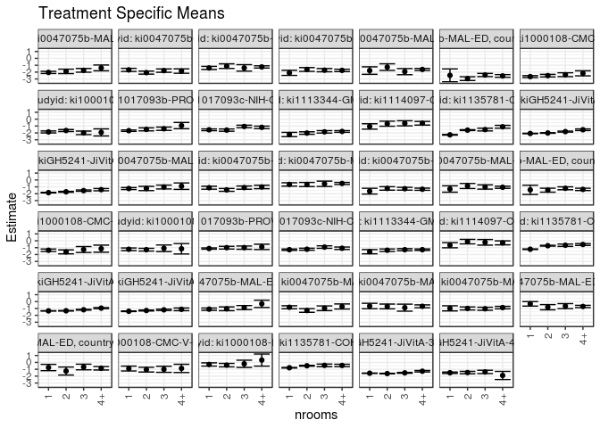

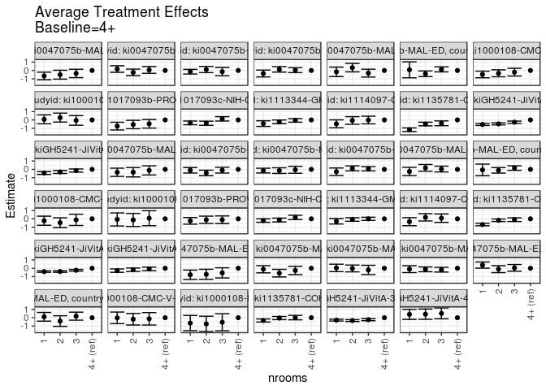

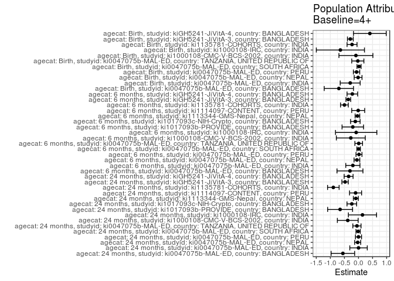

## Results Table

### Parameter: TSM

| agecat | studyid | country | intervention_level | baseline_level | estimate | ci_lower | ci_upper |
| --- | --- | --- | --- | --- | --- | --- | --- |
| Birth | ki0047075b-MAL-ED | BANGLADESH | 4+ | NA | -0.3258334 | -0.8578198 | 0.2061531 |
| Birth | ki0047075b-MAL-ED | BANGLADESH | 1 | NA | -1.1008333 | -1.2671941 | -0.9344726 |
| Birth | ki0047075b-MAL-ED | BANGLADESH | 2 | NA | -1.0478000 | -1.3207804 | -0.7748196 |
| Birth | ki0047075b-MAL-ED | BANGLADESH | 3 | NA | -0.8767857 | -1.1713221 | -0.5822493 |
| Birth | ki0047075b-MAL-ED | INDIA | 4+ | NA | -0.7122727 | -1.0804476 | -0.3440979 |
| Birth | ki0047075b-MAL-ED | INDIA | 1 | NA | -0.8304348 | -1.0493061 | -0.6115635 |
| Birth | ki0047075b-MAL-ED | INDIA | 2 | NA | -1.2973529 | -1.5619290 | -1.0327768 |
| Birth | ki0047075b-MAL-ED | INDIA | 3 | NA | -0.9731250 | -1.3118441 | -0.6344059 |
| Birth | ki0047075b-MAL-ED | NEPAL | 4+ | NA | -0.6861856 | -0.8921831 | -0.4801880 |
| Birth | ki0047075b-MAL-ED | NEPAL | 1 | NA | -0.6447222 | -1.0363484 | -0.2530960 |
| Birth | ki0047075b-MAL-ED | NEPAL | 2 | NA | -0.7085714 | -1.0577177 | -0.3594251 |
| Birth | ki0047075b-MAL-ED | NEPAL | 3 | NA | -0.8841176 | -1.3957332 | -0.3725021 |
| Birth | ki0047075b-MAL-ED | PERU | 4+ | NA | -0.8753030 | -1.0543832 | -0.6962228 |
| Birth | ki0047075b-MAL-ED | PERU | 1 | NA | -0.9841176 | -1.3534415 | -0.6147938 |
| Birth | ki0047075b-MAL-ED | PERU | 2 | NA | -1.0001961 | -1.2218151 | -0.7785771 |
| Birth | ki0047075b-MAL-ED | PERU | 3 | NA | -1.0410169 | -1.2599595 | -0.8220744 |
| Birth | ki0047075b-MAL-ED | SOUTH AFRICA | 4+ | NA | -0.7115625 | -0.8742865 | -0.5488385 |
| Birth | ki0047075b-MAL-ED | SOUTH AFRICA | 1 | NA | -0.3292857 | -0.6577384 | -0.0008331 |
| Birth | ki0047075b-MAL-ED | SOUTH AFRICA | 2 | NA | -0.8176190 | -1.1978709 | -0.4373672 |
| Birth | ki0047075b-MAL-ED | SOUTH AFRICA | 3 | NA | -0.6600000 | -1.0222494 | -0.2977506 |
| Birth | ki0047075b-MAL-ED | TANZANIA, UNITED REPUBLIC OF | 4+ | NA | -0.8570909 | -1.1055082 | -0.6086736 |
| Birth | ki0047075b-MAL-ED | TANZANIA, UNITED REPUBLIC OF | 1 | NA | -0.7483333 | -1.2065156 | -0.2901510 |
| Birth | ki0047075b-MAL-ED | TANZANIA, UNITED REPUBLIC OF | 2 | NA | -1.2562500 | -1.8386352 | -0.6738648 |
| Birth | ki0047075b-MAL-ED | TANZANIA, UNITED REPUBLIC OF | 3 | NA | -0.6721212 | -1.0804186 | -0.2638238 |
| Birth | ki1000108-CMC-V-BCS-2002 | INDIA | 4+ | NA | -0.8740000 | -1.4740637 | -0.2739363 |
| Birth | ki1000108-CMC-V-BCS-2002 | INDIA | 1 | NA | -0.8934211 | -1.2443816 | -0.5424605 |
| Birth | ki1000108-CMC-V-BCS-2002 | INDIA | 2 | NA | -1.0532143 | -1.3981109 | -0.7083176 |
| Birth | ki1000108-CMC-V-BCS-2002 | INDIA | 3 | NA | -1.0042105 | -1.4477729 | -0.5606481 |
| Birth | ki1000108-IRC | INDIA | 4+ | NA | 0.3352941 | -0.5439061 | 1.2144943 |
| Birth | ki1000108-IRC | INDIA | 1 | NA | -0.3042286 | -0.5400538 | -0.0684033 |

[output cut: 134 more lines]

### Parameter: E(Y)

| agecat | studyid | country | intervention_level | baseline_level | estimate | ci_lower | ci_upper |
| --- | --- | --- | --- | --- | --- | --- | --- |
| Birth | ki0047075b-MAL-ED | BANGLADESH | NA | NA | -1.0229487 | -1.1509575 | -0.8949400 |
| Birth | ki0047075b-MAL-ED | INDIA | NA | NA | -1.0069634 | -1.1525107 | -0.8614160 |
| Birth | ki0047075b-MAL-ED | NEPAL | NA | NA | -0.6998830 | -0.8579049 | -0.5418612 |
| Birth | ki0047075b-MAL-ED | PERU | NA | NA | -0.9447876 | -1.0604945 | -0.8290808 |
| Birth | ki0047075b-MAL-ED | SOUTH AFRICA | NA | NA | -0.6917890 | -0.8248091 | -0.5587689 |
| Birth | ki0047075b-MAL-ED | TANZANIA, UNITED REPUBLIC OF | NA | NA | -0.8810169 | -1.0869236 | -0.6751103 |
| Birth | ki1000108-CMC-V-BCS-2002 | INDIA | NA | NA | -0.9654444 | -1.1742112 | -0.7566777 |
| Birth | ki1000108-IRC | INDIA | NA | NA | -0.3079016 | -0.4694769 | -0.1463262 |
| Birth | ki1135781-COHORTS | INDIA | NA | NA | -0.6777626 | -0.7107167 | -0.6448086 |
| Birth | kiGH5241-JiVitA-3 | BANGLADESH | NA | NA | -1.5751978 | -1.5949779 | -1.5554177 |
| Birth | kiGH5241-JiVitA-4 | BANGLADESH | NA | NA | -1.4976642 | -1.5817349 | -1.4135935 |
| 6 months | ki0047075b-MAL-ED | BANGLADESH | NA | NA | -1.2033681 | -1.3212429 | -1.0854932 |
| 6 months | ki0047075b-MAL-ED | INDIA | NA | NA | -1.2159433 | -1.3345235 | -1.0973630 |
| 6 months | ki0047075b-MAL-ED | NEPAL | NA | NA | -0.5610593 | -0.6737915 | -0.4483272 |
| 6 months | ki0047075b-MAL-ED | PERU | NA | NA | -1.3280247 | -1.4371552 | -1.2188942 |
| 6 months | ki0047075b-MAL-ED | SOUTH AFRICA | NA | NA | -1.0548494 | -1.1845497 | -0.9251491 |
| 6 months | ki0047075b-MAL-ED | TANZANIA, UNITED REPUBLIC OF | NA | NA | -1.3601215 | -1.4821830 | -1.2380600 |
| 6 months | ki1000108-CMC-V-BCS-2002 | INDIA | NA | NA | -1.4234508 | -1.5645974 | -1.2823042 |
| 6 months | ki1000108-IRC | INDIA | NA | NA | -1.2470123 | -1.3779341 | -1.1160906 |
| 6 months | ki1017093b-PROVIDE | BANGLADESH | NA | NA | -1.0871041 | -1.1635539 | -1.0106543 |
| 6 months | ki1017093c-NIH-Crypto | BANGLADESH | NA | NA | -1.1986783 | -1.2700937 | -1.1272630 |
| 6 months | ki1113344-GMS-Nepal | NEPAL | NA | NA | -1.3321522 | -1.4103691 | -1.2539352 |
| 6 months | ki1114097-CONTENT | PERU | NA | NA | -0.3139217 | -0.4868486 | -0.1409948 |
| 6 months | ki1135781-COHORTS | INDIA | NA | NA | -1.0413281 | -1.0740395 | -1.0086167 |
| 6 months | kiGH5241-JiVitA-3 | BANGLADESH | NA | NA | -1.3132988 | -1.3364412 | -1.2901565 |
| 6 months | kiGH5241-JiVitA-4 | BANGLADESH | NA | NA | -1.3440477 | -1.3813060 | -1.3067894 |
| 24 months | ki0047075b-MAL-ED | BANGLADESH | NA | NA | -1.9431132 | -2.0691678 | -1.8170586 |
| 24 months | ki0047075b-MAL-ED | INDIA | NA | NA | -1.8458150 | -1.9718703 | -1.7197596 |
| 24 months | ki0047075b-MAL-ED | NEPAL | NA | NA | -1.2752193 | -1.3954783 | -1.1549603 |
| 24 months | ki0047075b-MAL-ED | PERU | NA | NA | -1.7500995 | -1.8705474 | -1.6296516 |
| 24 months | ki0047075b-MAL-ED | SOUTH AFRICA | NA | NA | -1.6228361 | -1.7581177 | -1.4875546 |
| 24 months | ki0047075b-MAL-ED | TANZANIA, UNITED REPUBLIC OF | NA | NA | -2.6058879 | -2.7403043 | -2.4714714 |
| 24 months | ki1000108-CMC-V-BCS-2002 | INDIA | NA | NA | -2.5593683 | -2.6601027 | -2.4586339 |
| 24 months | ki1000108-IRC | INDIA | NA | NA | -1.7853686 | -1.8795723 | -1.6911648 |
| 24 months | ki1017093b-PROVIDE | BANGLADESH | NA | NA | -1.5861179 | -1.6693668 | -1.5028689 |
| 24 months | ki1017093c-NIH-Crypto | BANGLADESH | NA | NA | -1.4295331 | -1.5127726 | -1.3462935 |
| 24 months | ki1113344-GMS-Nepal | NEPAL | NA | NA | -1.8835905 | -1.9681499 | -1.7990312 |
| 24 months | ki1114097-CONTENT | PERU | NA | NA | -0.6962195 | -0.8674103 | -0.5250287 |
| 24 months | ki1135781-COHORTS | INDIA | NA | NA | -2.0008909 | -2.0401990 | -1.9615828 |
| 24 months | kiGH5241-JiVitA-3 | BANGLADESH | NA | NA | -2.0127436 | -2.0404564 | -1.9850309 |
| 24 months | kiGH5241-JiVitA-4 | BANGLADESH | NA | NA | -1.7578934 | -1.7933205 | -1.7224663 |

### Parameter: ATE

| agecat | studyid | country | intervention_level | baseline_level | estimate | ci_lower | ci_upper |
| --- | --- | --- | --- | --- | --- | --- | --- |
| Birth | ki0047075b-MAL-ED | BANGLADESH | 4+ | 4+ | 0.0000000 | 0.0000000 | 0.0000000 |
| Birth | ki0047075b-MAL-ED | BANGLADESH | 1 | 4+ | -0.7750000 | -1.3323916 | -0.2176083 |
| Birth | ki0047075b-MAL-ED | BANGLADESH | 2 | 4+ | -0.7219666 | -1.3199030 | -0.1240303 |
| Birth | ki0047075b-MAL-ED | BANGLADESH | 3 | 4+ | -0.5509523 | -1.1590323 | 0.0571276 |
| Birth | ki0047075b-MAL-ED | INDIA | 4+ | 4+ | 0.0000000 | 0.0000000 | 0.0000000 |
| Birth | ki0047075b-MAL-ED | INDIA | 1 | 4+ | -0.1181621 | -0.5464813 | 0.3101572 |
| Birth | ki0047075b-MAL-ED | INDIA | 2 | 4+ | -0.5850802 | -1.0384600 | -0.1317004 |
| Birth | ki0047075b-MAL-ED | INDIA | 3 | 4+ | -0.2608523 | -0.7611355 | 0.2394310 |
| Birth | ki0047075b-MAL-ED | NEPAL | 4+ | 4+ | 0.0000000 | 0.0000000 | 0.0000000 |
| Birth | ki0047075b-MAL-ED | NEPAL | 1 | 4+ | 0.0414633 | -0.4010365 | 0.4839632 |
| Birth | ki0047075b-MAL-ED | NEPAL | 2 | 4+ | -0.0223859 | -0.4277723 | 0.3830005 |
| Birth | ki0047075b-MAL-ED | NEPAL | 3 | 4+ | -0.1979321 | -0.7494622 | 0.3535980 |
| Birth | ki0047075b-MAL-ED | PERU | 4+ | 4+ | 0.0000000 | 0.0000000 | 0.0000000 |
| Birth | ki0047075b-MAL-ED | PERU | 1 | 4+ | -0.1088146 | -0.5192654 | 0.3016362 |
| Birth | ki0047075b-MAL-ED | PERU | 2 | 4+ | -0.1248930 | -0.4098224 | 0.1600363 |
| Birth | ki0047075b-MAL-ED | PERU | 3 | 4+ | -0.1657139 | -0.4485665 | 0.1171387 |
| Birth | ki0047075b-MAL-ED | SOUTH AFRICA | 4+ | 4+ | 0.0000000 | 0.0000000 | 0.0000000 |
| Birth | ki0047075b-MAL-ED | SOUTH AFRICA | 1 | 4+ | 0.3822768 | 0.0157249 | 0.7488286 |
| Birth | ki0047075b-MAL-ED | SOUTH AFRICA | 2 | 4+ | -0.1060565 | -0.5196634 | 0.3075503 |
| Birth | ki0047075b-MAL-ED | SOUTH AFRICA | 3 | 4+ | 0.0515625 | -0.3455568 | 0.4486818 |
| Birth | ki0047075b-MAL-ED | TANZANIA, UNITED REPUBLIC OF | 4+ | 4+ | 0.0000000 | 0.0000000 | 0.0000000 |
| Birth | ki0047075b-MAL-ED | TANZANIA, UNITED REPUBLIC OF | 1 | 4+ | 0.1087576 | -0.4124355 | 0.6299506 |
| Birth | ki0047075b-MAL-ED | TANZANIA, UNITED REPUBLIC OF | 2 | 4+ | -0.3991591 | -1.0323128 | 0.2339946 |
| Birth | ki0047075b-MAL-ED | TANZANIA, UNITED REPUBLIC OF | 3 | 4+ | 0.1849697 | -0.2929612 | 0.6629006 |
| Birth | ki1000108-CMC-V-BCS-2002 | INDIA | 4+ | 4+ | 0.0000000 | 0.0000000 | 0.0000000 |
| Birth | ki1000108-CMC-V-BCS-2002 | INDIA | 1 | 4+ | -0.0194211 | -0.7145827 | 0.6757406 |
| Birth | ki1000108-CMC-V-BCS-2002 | INDIA | 2 | 4+ | -0.1792143 | -0.8713343 | 0.5129057 |
| Birth | ki1000108-CMC-V-BCS-2002 | INDIA | 3 | 4+ | -0.1302105 | -0.8764169 | 0.6159959 |
| Birth | ki1000108-IRC | INDIA | 4+ | 4+ | 0.0000000 | 0.0000000 | 0.0000000 |
| Birth | ki1000108-IRC | INDIA | 1 | 4+ | -0.6395227 | -1.5498010 | 0.2707556 |

[output cut: 134 more lines]

### Parameter: PAR

| agecat | studyid | country | intervention_level | baseline_level | estimate | ci_lower | ci_upper |
| --- | --- | --- | --- | --- | --- | --- | --- |
| Birth | ki0047075b-MAL-ED | BANGLADESH | 4+ | NA | -0.6971154 | -1.2170857 | -0.1771450 |
| Birth | ki0047075b-MAL-ED | INDIA | 4+ | NA | -0.2946906 | -0.6489645 | 0.0595832 |
| Birth | ki0047075b-MAL-ED | NEPAL | 4+ | NA | -0.0136975 | -0.1524897 | 0.1250947 |
| Birth | ki0047075b-MAL-ED | PERU | 4+ | NA | -0.0694846 | -0.1824845 | 0.0435152 |
| Birth | ki0047075b-MAL-ED | SOUTH AFRICA | 4+ | NA | 0.0197735 | -0.0530623 | 0.0926093 |
| Birth | ki0047075b-MAL-ED | TANZANIA, UNITED REPUBLIC OF | 4+ | NA | -0.0239260 | -0.2397531 | 0.1919011 |
| Birth | ki1000108-CMC-V-BCS-2002 | INDIA | 4+ | NA | -0.0914444 | -0.6944797 | 0.5115908 |
| Birth | ki1000108-IRC | INDIA | 4+ | NA | -0.6431957 | -1.4981881 | 0.2117968 |
| Birth | ki1135781-COHORTS | INDIA | 4+ | NA | -0.2287409 | -0.4057604 | -0.0517214 |
| Birth | kiGH5241-JiVitA-3 | BANGLADESH | 4+ | NA | -0.2894786 | -0.3924084 | -0.1865489 |
| Birth | kiGH5241-JiVitA-4 | BANGLADESH | 4+ | NA | 0.4038742 | -0.1775319 | 0.9852804 |
| 6 months | ki0047075b-MAL-ED | BANGLADESH | 4+ | NA | -0.3026736 | -0.7633106 | 0.1579634 |
| 6 months | ki0047075b-MAL-ED | INDIA | 4+ | NA | -0.2000099 | -0.4517608 | 0.0517409 |
| 6 months | ki0047075b-MAL-ED | NEPAL | 4+ | NA | -0.0558939 | -0.1570156 | 0.0452277 |
| 6 months | ki0047075b-MAL-ED | PERU | 4+ | NA | 0.0183422 | -0.0873657 | 0.1240501 |
| 6 months | ki0047075b-MAL-ED | SOUTH AFRICA | 4+ | NA | 0.0046750 | -0.0576106 | 0.0669606 |
| 6 months | ki0047075b-MAL-ED | TANZANIA, UNITED REPUBLIC OF | 4+ | NA | 0.0082427 | -0.1274159 | 0.1439014 |
| 6 months | ki1000108-CMC-V-BCS-2002 | INDIA | 4+ | NA | -0.2727365 | -0.7868576 | 0.2413846 |
| 6 months | ki1000108-IRC | INDIA | 4+ | NA | -0.0825025 | -0.8172636 | 0.6522585 |
| 6 months | ki1017093b-PROVIDE | BANGLADESH | 4+ | NA | -0.2018660 | -0.5837692 | 0.1800372 |
| 6 months | ki1017093c-NIH-Crypto | BANGLADESH | 4+ | NA | -0.1123596 | -0.2818458 | 0.0571266 |
| 6 months | ki1113344-GMS-Nepal | NEPAL | 4+ | NA | -0.0378013 | -0.1200075 | 0.0444048 |
| 6 months | ki1114097-CONTENT | PERU | 4+ | NA | -0.0104623 | -0.2406643 | 0.2197396 |
| 6 months | ki1135781-COHORTS | INDIA | 4+ | NA | -0.4996077 | -0.6374107 | -0.3618046 |
| 6 months | kiGH5241-JiVitA-3 | BANGLADESH | 4+ | NA | -0.3622235 | -0.4456442 | -0.2788029 |
| 6 months | kiGH5241-JiVitA-4 | BANGLADESH | 4+ | NA | -0.2186278 | -0.4063979 | -0.0308578 |
| 24 months | ki0047075b-MAL-ED | BANGLADESH | 4+ | NA | -0.5549314 | -0.9732601 | -0.1366027 |
| 24 months | ki0047075b-MAL-ED | INDIA | 4+ | NA | 0.0017850 | -0.3085150 | 0.3120851 |
| 24 months | ki0047075b-MAL-ED | NEPAL | 4+ | NA | -0.0287626 | -0.1362280 | 0.0787028 |
| 24 months | ki0047075b-MAL-ED | PERU | 4+ | NA | 0.0000369 | -0.1080604 | 0.1081341 |
| 24 months | ki0047075b-MAL-ED | SOUTH AFRICA | 4+ | NA | -0.0128088 | -0.0888685 | 0.0632509 |
| 24 months | ki0047075b-MAL-ED | TANZANIA, UNITED REPUBLIC OF | 4+ | NA | -0.0552246 | -0.2009514 | 0.0905023 |
| 24 months | ki1000108-CMC-V-BCS-2002 | INDIA | 4+ | NA | -0.3811540 | -0.7505083 | -0.0117997 |
| 24 months | ki1000108-IRC | INDIA | 4+ | NA | 0.1415922 | -0.3593490 | 0.6425334 |
| 24 months | ki1017093b-PROVIDE | BANGLADESH | 4+ | NA | -0.6529360 | -1.0961445 | -0.2097275 |
| 24 months | ki1017093c-NIH-Crypto | BANGLADESH | 4+ | NA | -0.2370940 | -0.4079858 | -0.0662023 |
| 24 months | ki1113344-GMS-Nepal | NEPAL | 4+ | NA | -0.0942867 | -0.1830156 | -0.0055578 |
| 24 months | ki1114097-CONTENT | PERU | 4+ | NA | -0.1036005 | -0.3177075 | 0.1105066 |
| 24 months | ki1135781-COHORTS | INDIA | 4+ | NA | -0.8932593 | -1.0986871 | -0.6878315 |
| 24 months | kiGH5241-JiVitA-3 | BANGLADESH | 4+ | NA | -0.4762859 | -0.5887967 | -0.3637750 |
| 24 months | kiGH5241-JiVitA-4 | BANGLADESH | 4+ | NA | -0.3504034 | -0.5087660 | -0.1920407 |